# Прохождение внешнего курса

Презентация

Виноградова М.А

Российский университет дружбы народов, Москва, Россия

15 мая 2026

# Информация

## Докладчик

- Виноградова Мария Андреевна
- студентка НПИбд-01-24
- номер студ. билета 1132240691
- Российский университет дружбы народов
- 1132240691@pfur.ru
- https://github.com/mavinogradova/study_2024-2025_infosec-intro

# Презентаия по курсу «Основы кибербезопасности»

## 1.1 О курсе

Курс включает разделы: безопасность в сети (протоколы, TOR, Wi-Fi), защита ПК и телефона (шифрование, пароли, фишинг, вирусы, мессенджеры) и криптография на практике (цифровая подпись, электронные платежи, блокчейн).

[figure not shown]

## Блок 2. Безопасность в сети

**О чем блок:** Блок объясняет, как работает интернет, какие протоколы обеспечивают передачу данных, как происходит персонализация через куки, что такое TOR и анонимность, а также как защищены беспроводные сети Wi-Fi.

## 2.1 Как работает интернет: базовые сетевые протоколы

**Теория:** В интернете данные передаются по модели TCP/IP. Протоколы делятся на уровни: прикладной (HTTP, HTTPS), транспортный (TCP), сетевой (IP) и канальный. HTTPS шифрует данные, а версия TLS согласуется клиентом и сервером.

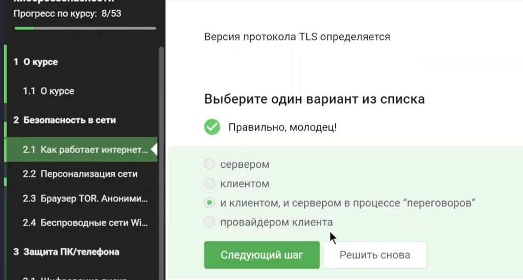

Задания выплнены

## 2.2 Персонализация сети

**Теория:** Куки (cookies) — это небольшие файлы, которые сервер сохраняет в браузере пользователя. Они используются для аутентификации, персонализации, отслеживания и сбора статистики, но не влияют на надёжность соединения.

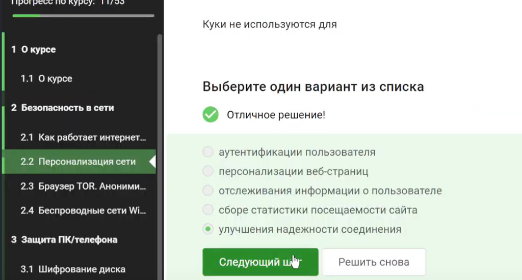

Задания выполнены

## 2.3 Браузер TOR. Анонимность

**Теория:** TOR (The Onion Router) обеспечивает анонимность за счёт луковой маршрутизации — данные проходят через три промежуточных узла с многоуровневым шифрованием. Получателю не обязательно использовать TOR.

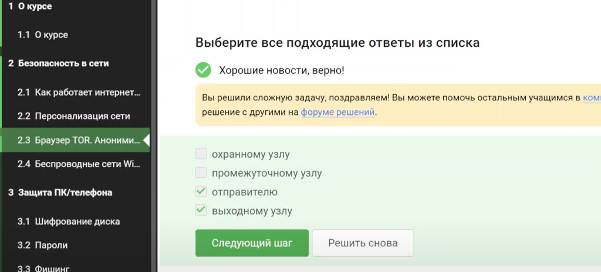

Задания выполнены

## 2.4 Беспроводные сети Wi-Fi

**Теория:** Wi-Fi — технология беспроводной локальной сети (стандарт IEEE 802.11), работающая на канальном уровне. Безопасность обеспечивается протоколами шифрования: WEP (небезопасен), WPA2/WPA3. Домашние сети используют WPA2 Personal.

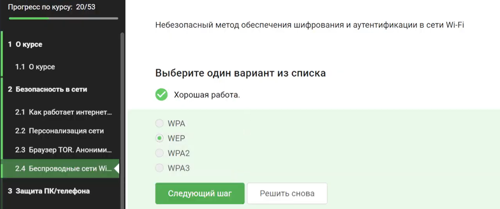

Задания выполнены

## Блок 3. Защита ПК и телефона

**С чем знакомит блок:** Блок учит защищать устройства: шифровать диски, создавать стойкие пароли, распознавать фишинг, понимать принципы работы вирусов и безопасно использовать мессенджеры.

## 3.1 Шифрование диска

**Теория:** Шифрование диска защищает данные при физическом доступе к устройству. Чаще всего используется симметричное шифрование, где один ключ и шифрует, и расшифровывает данные.

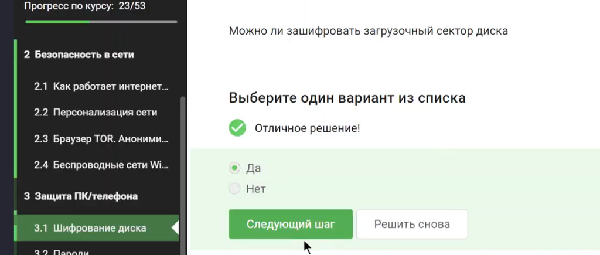

Задания выполнены

## 3.2 Пароли

**Теория:** Стойкий пароль содержит буквы разного регистра, цифры и спецсимволы. Пароли безопасно хранить в менеджерах паролей. Капча защищает от автоматических атак, хэширование позволяет не хранить пароли в открытом виде, а «соль» усложняет перебор даже при утечке базы данных.

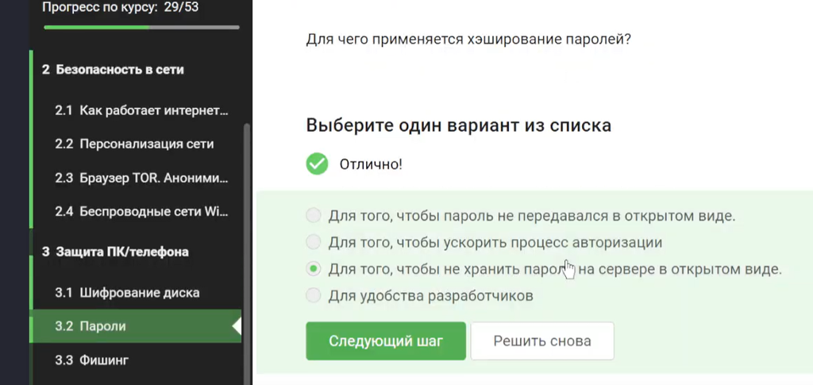

Задания выполнены

## 3.3 Фишинг

**Теория:** Фишинг — вид атак, где злоумышленники пытаются получить пароли, данные банковских карт и другую конфиденциальную информацию. Они могут подделывать адрес отправителя, поэтому письмо может прийти от знакомого адреса.

[figure not shown]

Задания выполнены

## 3.4 Вирусы. Примеры

**Теория:** Трояны маскируются под легитимные программы. Email-спуфинг — подмена адреса отправителя для обмана получателя.

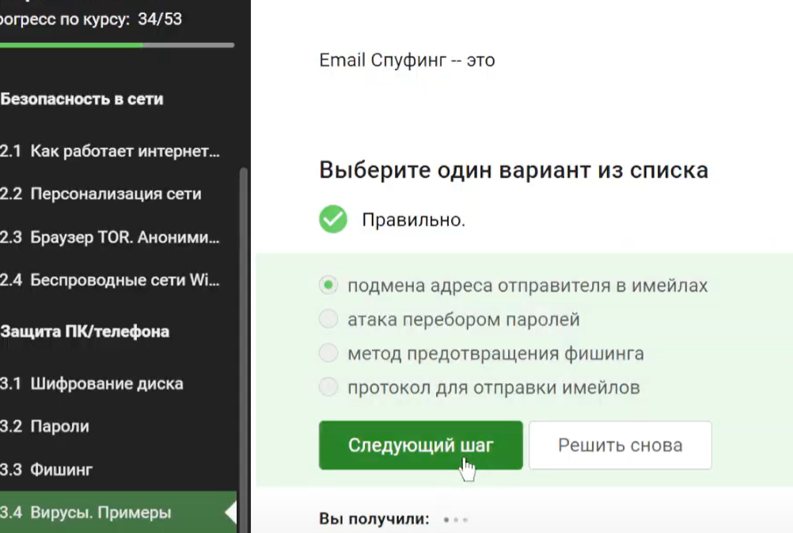

Задания выполнены

## 3.5 Безопасность мессенджеров

**Теория:** Сквозное шифрование (end-to-end) гарантирует, что даже сервер не видит содержимое сообщений. В протоколе Signal ключ шифрования формируется для каждого нового сообщения отдельно.

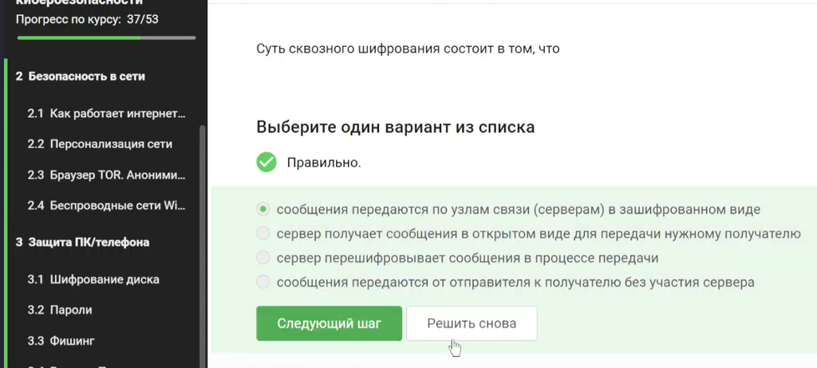

Задания выполнены

## Блок 4. Криптография на практике

**С чем знакомит блок:** Блок раскрывает основы криптографии: симметричные и асимметричные алгоритмы, цифровые подписи, электронные платежи и блокчейн.

## 4.1 Введение в криптографию

**Теория:** В асимметричной криптографии у каждой стороны есть пара ключей (открытый и закрытый). Код аутентификации сообщений (MAC) относится к симметричным примитивам. Протокол Диффи-Хэллмана позволяет двум сторонам получить общий секретный ключ через открытый канал.

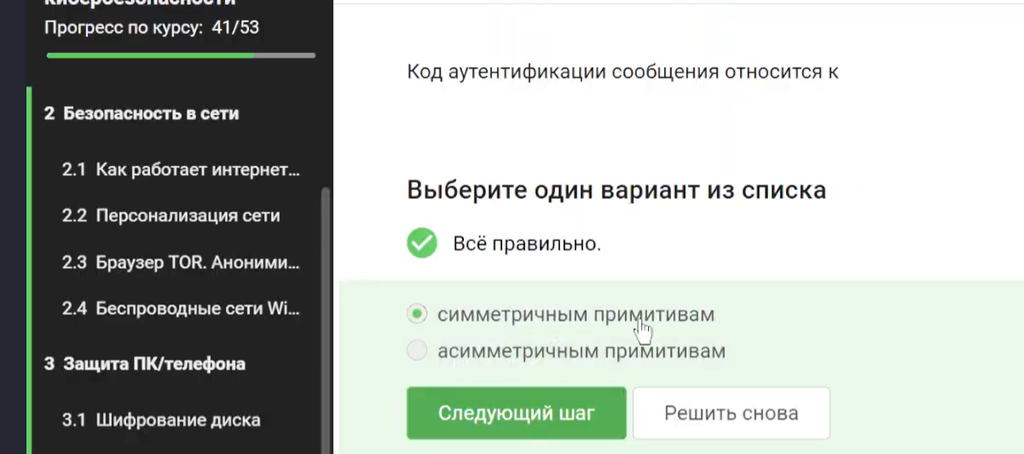

Задания выполнены

## 4.2 Цифровая подпись

**Теория:** Цифровая подпись относится к протоколам с открытым ключом. Для проверки подписи нужны сама подпись, открытый ключ и исходное сообщение. Сертификаты выдаются удостоверяющими центрами. Для налоговой отчётности требуется усиленная квалифицированная электронная подпись.

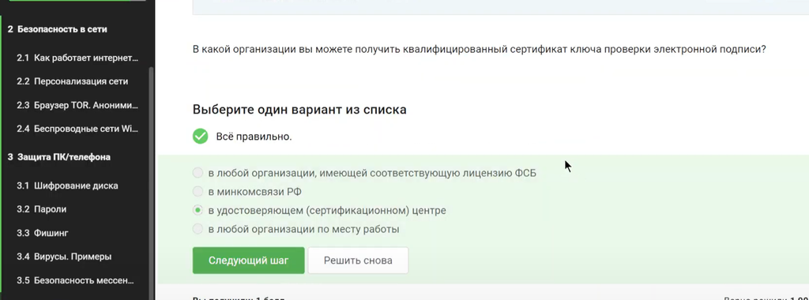

Задания выполнены

## 4.3 Электронные платежи

**Теория:** Электронные платежи используют платёжные системы (MasterCard, МИР) и методы многофакторной аутентификации (пароль + SMS, отпечаток пальца + SMS) для защиты транзакций.

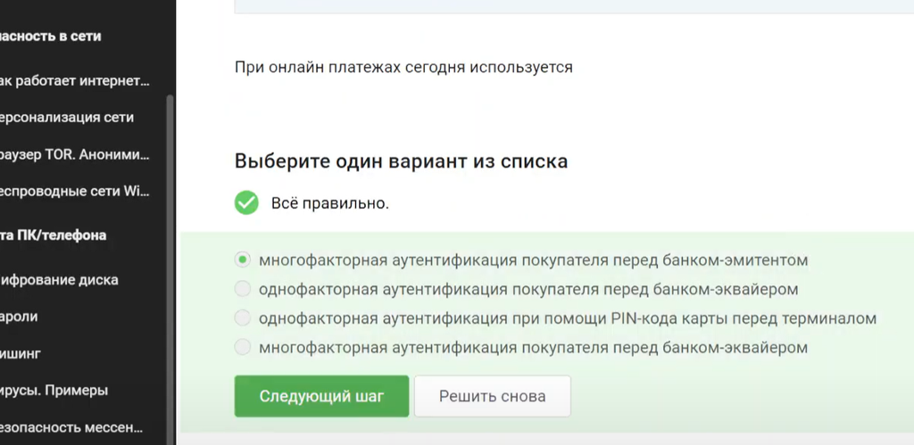

Задания выполнены

## 4.4 Блокчейн

**Теория:** В блокчейне доказательство работы (Proof-of-Work) основано на сложности нахождения прообраза хэш-функции. Консенсус обладает свойствами постоянства и живучести. Участники блокчейна хранят секретные ключи цифровой подписи.

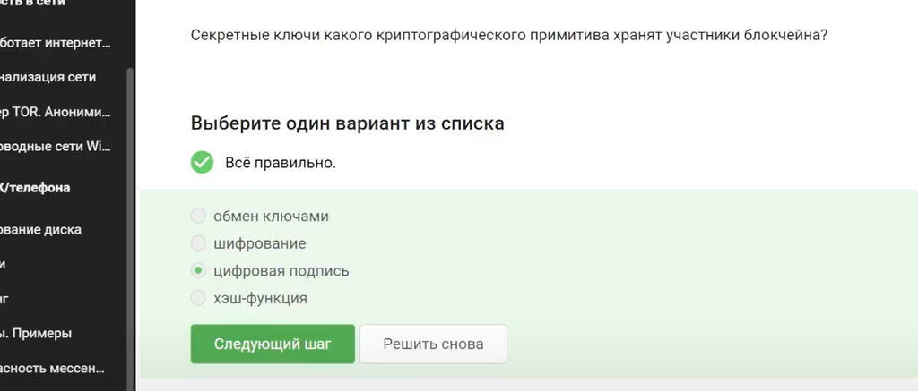

Задания выполнены

## Завершение курса

Курс «Основы кибербезопасности» пройден полностью. Результат: **53 балла из 53**, изучено 100% материалов.

[figure not shown]

Задания выполнены